# Wk6_Take_home

Sam Fritz-Schreck

2024-02-12

## The Situation

In this take-home lab, we’ll return to the “Match My Thesis” situation we used earlier in the quarter. However, we’ll solve a slightly different problem this time using the same data. The file StudentAbstracts.csv contains 16 abstract proposals submitted by students in the Defense Analysis Department at NPS. Your task is to group these 16 students into teams of three to five students that will meet together regularly over the year to discuss their thesis work. The goal is to group students according to the underlying topics/themes that their work explores within the larger context of research conducted within the DA Department over the last 10 years. The provided NPSTheses.csv document contains all of the theses completed at the Naval Postgraduate School over the last 40 years. Assignment

Complete the following tasks in order to group your students into appropriate teams:

```
Build a topic model for the DA Department Theses using the abstracts contained in NPSTheses.csv. Ignore any thesis not completed exclusively within the DA Department (i.e. joint theses conducted within multiple departments can be ignored) that has not been completed from 2010 to 2018.
```

```r
library(lubridate)
thesis_data = read.csv("./TH_Lab_Data/NPSTheses.csv")
DA_thesis = thesis_data[thesis_data$department=="Defense Analysis",]
DA_thesis[9263,]$date = "2000"
DA_thesis$date <- parse_date_time2(substr(DA_thesis$date, 1, 4),'Y',cutoff_2000 = 24)
abstracts = DA_thesis[DA_thesis$date>=parse_date_time2('2010',"Y"),]$abstract

prep_fun = function(x) {
  x %>%
    # make text lower case
    str_to_lower %>%
    # remove non-alphanumeric symbols
    str_replace_all("[^[:alnum:]]", " ") %>%
    # collapse multiple spaces
    str_replace_all("\\s+", " ")
}

# Create DTM for Base Documents
my_corpus<-prep_fun(abstracts)
my_corpus_it = itoken(my_corpus, progressbar = FALSE)
v = create_vocabulary(my_corpus_it, stopwords = c(stopwords('smart'),'s','u','al','thesis')) %>%  # note the removal of stopwords here
  prune_vocabulary(doc_proportion_max = 0.05, term_count_min = 5)   # set some thresholds for minimum occurrence
vectorizer = vocab_vectorizer(v)
my_corpus_dtm<-create_dtm(my_corpus_it, vectorizer)   # build a DTM

# Parameterize and Fit the LDA Model - note this will not run with topicmodels package loaded
lda_model = LDA$new(n_topics = 10)

# The document - topic distribution
doc_topic_distr = lda_model$fit_transform(my_corpus_dtm, n_iter = 200)
```

```
## INFO  [12:50:49.689] early stopping at 90 iteration
## INFO  [12:50:49.760] early stopping at 30 iteration
```

```r
# The topic - word distribution
topic_word_dist <- lda_model$topic_word_distribution
dim(topic_word_dist)
```

```
## [1]   10 1427
```

```r
library(servr)
lda_model$get_top_words()
```

```
##       [,1]           [,2]         [,3]           [,4]          [,5]
##  [1,] "military"     "time"       "strategic"    "influence"   "conflict"
##  [2,] "intelligence" "based"      "national"     "information" "government"
##  [3,] "training"     "system"     "defense"      "social"      "state"
##  [4,] "doctrine"     "provide"    "level"        "future"      "countries"
##  [5,] "operational"  "historical" "effective"    "policy"      "colombia"
##  [6,] "environment"  "current"    "nato"         "approach"    "study"
##  [7,] "current"      "term"       "programs"     "support"     "stability"
##  [8,] "nation"       "long"       "capabilities" "examines"    "political"
##  [9,] "officers"     "years"      "decision"     "population"  "important"
## [10,] "force"        "nsw"        "support"      "success"     "order"
##       [,6]         [,7]       [,8]            [,9]        [,10]
##  [1,] "study"      "network"  "terrorist"     "states"    "operations"
##  [2,] "research"   "analysis" "organizations" "warfare"   "forces"
##  [3,] "violence"   "theory"   "international" "strategy"  "special"
##  [4,] "groups"     "social"   "organization"  "united"    "sof"
##  [5,] "case"       "networks" "iran"          "war"       "army"
##  [6,] "leadership" "civil"    "security"      "irregular" "security"
##  [7,] "analysis"   "process"  "terrorism"     "military"  "command"
##  [8,] "insurgent"  "data"     "region"        "power"     "force"
##  [9,] "violent"    "design"   "threat"        "state"     "development"
## [10,] "leaders"    "china"    "regional"      "threats"   "recommendations"
```

```r
# Plot results - note that Topic numbers in this plot don't correlate with columns in matrices
lda_model$plot()
```

```r
### Take a look at perplexity scores as we add more topics
perplexity_list <- list()
topic_numbers <- c(5, 10, 15, 20, 25, 30, 35, 40, 45, 50)
counter <- 1
for (i in topic_numbers){
  lda_model = LDA$new(n_topics = i)
  # The document - topic distribution
  doc_topic_distr = lda_model$fit_transform(my_corpus_dtm, n_iter = 200)
  topic_word_dist <- lda_model$topic_word_distribution
  perplexity_list[[counter]] <- perplexity(my_corpus_dtm, topic_word_dist, doc_topic_distr)
  counter <- counter + 1
}
```

```
## INFO  [12:50:50.213] early stopping at 50 iteration
## INFO  [12:50:50.238] early stopping at 20 iteration
## INFO  [12:50:50.437] early stopping at 120 iteration
## INFO  [12:50:50.474] early stopping at 20 iteration
## INFO  [12:50:50.654] early stopping at 100 iteration
## INFO  [12:50:50.696] early stopping at 30 iteration
## INFO  [12:50:50.862] early stopping at 70 iteration
## INFO  [12:50:50.910] early stopping at 30 iteration
## INFO  [12:50:51.105] early stopping at 80 iteration
## INFO  [12:50:51.140] early stopping at 20 iteration
## INFO  [12:50:51.447] early stopping at 130 iteration
## INFO  [12:50:51.500] early stopping at 30 iteration
## INFO  [12:50:51.715] early stopping at 70 iteration
## INFO  [12:50:51.756] early stopping at 20 iteration
## INFO  [12:50:52.178] early stopping at 80 iteration
## INFO  [12:50:52.242] early stopping at 30 iteration
## INFO  [12:50:52.688] early stopping at 80 iteration
## INFO  [12:50:52.755] early stopping at 30 iteration
## INFO  [12:50:53.044] early stopping at 90 iteration
## INFO  [12:50:53.112] early stopping at 30 iteration
```

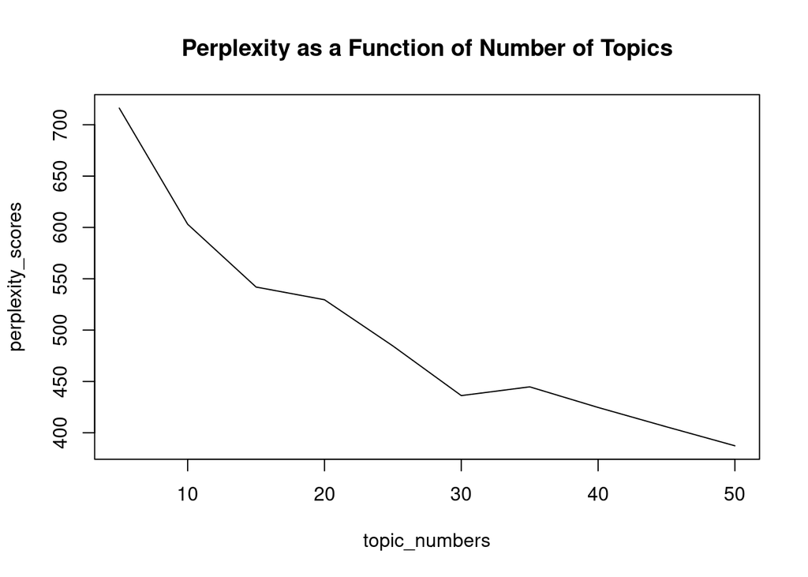

```r
# Collect up our results
perplexity_scores <- do.call(rbind, perplexity_list)

# Generate a plot
plot(topic_numbers, perplexity_scores,  main = "Perplexity as a Function of Number of Topics", type = 'l')
```

```r
##### Create a Perplexity Plot Function
perplexity_plot <- function(){
  perplexity_list <- list()
  topic_numbers <- c(5, 10, 15, 20, 25, 30, 35, 40, 45, 50)
  counter <- 1
  for (i in topic_numbers){
    lda_model = LDA$new(n_topics = i)
    # The document - topic distribution
    doc_topic_distr = lda_model$fit_transform(my_corpus_dtm, n_iter = 200)
    topic_word_dist <- lda_model$topic_word_distribution
    perplexity_list[[counter]] <- perplexity(my_corpus_dtm, topic_word_dist, doc_topic_distr)
    counter <- counter + 1
  }

  perplexity_scores <- do.call(rbind, perplexity_list)

  lines(topic_numbers, perplexity_scores, col='#FF000070')  # creates transparent lines
}
# Now Generate a perplexity plot from many different simulation runs
# Generate a plot
plot(topic_numbers, perplexity_scores,  main = "Perplexity as a Function of Number of Topics", type = 'l')
for (j in 1:50){
  print(j)
  perplexity_plot()
}
```

[output not shown]

## Use this topic model to group your students into teams of 3-5 students each.

```r
# Parameterize and Fit the LDA Model - note this will not run with topicmodels package loaded
lda_model = LDA$new(n_topics = 10)

# The document - topic distribution
doc_topic_distr = lda_model$fit_transform(my_corpus_dtm, n_iter = 200)
```

```
## INFO  [12:50:53.379] early stopping at 60 iteration
## INFO  [12:50:53.407] early stopping at 20 iteration
```

```r
# The topic - word distribution
topic_word_dist <- lda_model$topic_word_distribution
abstracts_new <- read.csv('./TH_Lab_Data/StudentAbstracts.csv')  # Initialize a list to store the data

my_proposals<-prep_fun(abstracts_new$Abstract)
my_proposals_it = itoken(my_proposals, progressbar = FALSE)
my_proposals_dtm<-create_dtm(my_proposals_it, vectorizer)   # build a DTM using previous vectorizer
dim(my_proposals_dtm)       # note that DTM has same number of columns as previous DTM
```

```
## [1]   16 1427
```

```r
new_doc_topic_distr  = lda_model$transform(my_proposals_dtm)  # fits model to new data
```

```
## INFO  [12:50:53.460] early stopping at 20 iteration
```

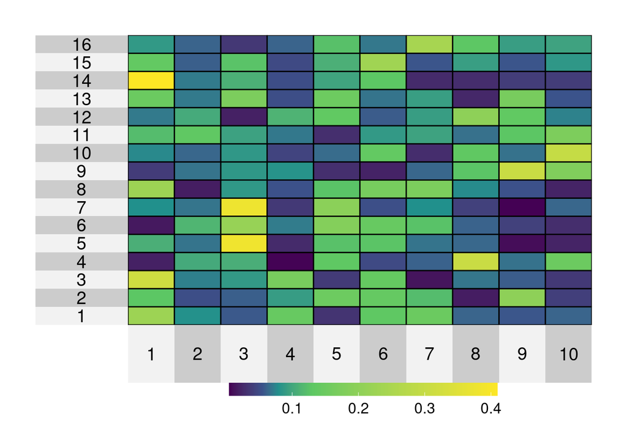

```r
### Build a plot that maps new observations to topic
superheat(new_doc_topic_distr)
```

```r
max_clusters <- 5  # Maximum number of clusters
set.seed(123)  # Set seed for reproducibility
clusters <- kmeans(new_doc_topic_distr, centers = max_clusters)

# View cluster assignments
cluster_assignments <- clusters$cluster
cluster_assignments
```

```
##  1  2  3  4  5  6  7  8  9 10 11 12 13 14 15 16
##  3  2  4  5  1  1  1  3  5  5  5  5  2  4  3  2
```

Provide written documentation (in your consolidated lab write-up) of your results/approach:

## Briefly describe and document how you selected the appropriate number of topics to represent work within the DA Deparment over the last 10 years (note that given our approach to the topic, there is no “best answer” here).

```r
### Take a look at perplexity scores as we add more topics
perplexity_list <- list()
topic_numbers <- c(5, 10, 15, 20, 25, 30, 35, 40, 45, 50)
counter <- 1
for (i in topic_numbers){
  lda_model2 = LDA$new(n_topics = i)
  # The document - topic distribution
  doc_topic_distr = lda_model2$fit_transform(my_corpus_dtm, n_iter = 200)
  topic_word_dist <- lda_model2$topic_word_distribution
  perplexity_list[[counter]] <- perplexity(my_corpus_dtm, topic_word_dist, doc_topic_distr)
  counter <- counter + 1
}
```

```
## INFO  [12:50:54.536] early stopping at 50 iteration
## INFO  [12:50:54.562] early stopping at 20 iteration
## INFO  [12:50:54.692] early stopping at 70 iteration
## INFO  [12:50:54.720] early stopping at 20 iteration
## INFO  [12:50:54.871] early stopping at 70 iteration
## INFO  [12:50:54.901] early stopping at 20 iteration
## INFO  [12:50:55.101] early stopping at 90 iteration
## INFO  [12:50:55.134] early stopping at 20 iteration
## INFO  [12:50:55.348] early stopping at 90 iteration
## INFO  [12:50:55.383] early stopping at 20 iteration
## INFO  [12:50:55.619] early stopping at 100 iteration
## INFO  [12:50:55.690] early stopping at 40 iteration
## INFO  [12:50:55.984] early stopping at 110 iteration
## INFO  [12:50:56.025] early stopping at 20 iteration
## INFO  [12:50:56.333] early stopping at 110 iteration
## INFO  [12:50:56.376] early stopping at 20 iteration
## INFO  [12:50:56.706] early stopping at 110 iteration
## INFO  [12:50:56.772] early stopping at 30 iteration
## INFO  [12:50:57.120] early stopping at 100 iteration
## INFO  [12:50:57.189] early stopping at 30 iteration
```

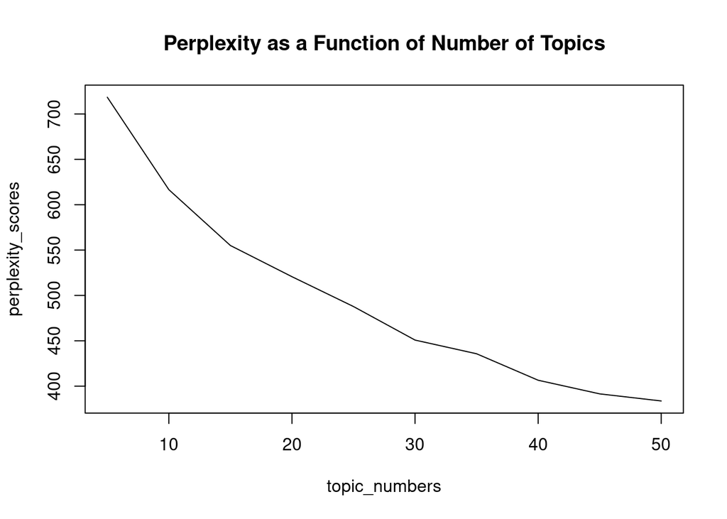

```r
# Collect up our results
perplexity_scores <- do.call(rbind, perplexity_list)

# Generate a plot
plot(topic_numbers, perplexity_scores,  main = "Perplexity as a Function of Number of Topics", type = 'l')
```

## Provide a table or graphic that summarizes one of the topics you’ve modeled. What would be a short title you would give to this topic? Briefly discuss the extent to which you feel this is a valid topic (or not) and why.

```r
# Assuming lda_model is your LDA model
lda_plot <- lda_model$plot()
```

### Special Operations Topic

[interactive chart not shown]

```
Provide tables/graphics that illustrate your method for grouping the 16 thesis students into teams. Briefly desribe how you went about making this decision (i.e. what is your method?).
```

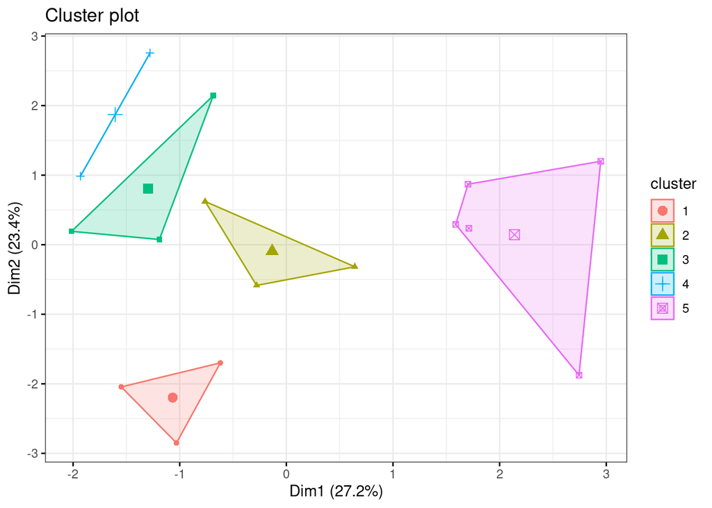

```r
fviz_cluster(clusters, data = new_doc_topic_distr,
             geom = "point",
             ellipse.type = "convex",
             ggtheme = theme_bw()
             )
```

## Briefly discuss the extent to which you think that topic modeling was useful/valid for this task.

Topic Modelling allowed me to deconstruct the students into unsupervised clusters. As with any unsupervised learning technique, I had to look at the individual clusters and either combine two clusters into one group as the topics are adjacent but not the same, or split a cluster due to a match as a result of similar language but the topics are not actually similar in spirit. It was useful for providing a starting point on the groups that I could then manually modify based on the requirement of 3-5 per group and more context from human experience.

## Briefly describe/summarize another approach that you could use to accomplish this task that is based on the subject matter we have discussed over the last three weeks (note that this might make a good course project); you do not need to implement this approach - simply describe the technques/procedures you could combine to provide an alternative grouping to that conducted above.

Submission Instructions

For this weekly lab assignment, you should submit:

```
An R sript file named Lastname_FirstInitial_TopicModeling.R that contains all of your code for the tasks above.

A written summary/discussion of your work (as discussed above) in .docx or .pdf format.
```